# CSCN8000 – Artificial Intelligence Algorithms and Mathematics

## Lab 3: California Housing Prices Prediction

- Student Name: George Mathew
- Student ID: 8966959
- Email ID: gmathew6959@conestogac.on.ca

## Data Preprocessing Tasks

### 1. Handle Outliers for “median_house_value”

- a. whiskers approach

```python
import pandas as pd
import numpy as np

# Load the dataset
data = pd.read_csv("C:/Users/ASUS/Documents/AAIML/Artificial Intelligence Algorithms and Mathematics/CSCN8000/Data/housing_dataset.csv")

print(f'Number of records: {len(data)}')

# Identifying outliers using the whiskers approach
q1 = data['median_house_value'].quantile(0.25)
q3 = data['median_house_value'].quantile(0.75)
iqr = q3 - q1
lower_whisker = q1 - 1.5 * iqr
upper_whisker = q3 + 1.5 * iqr

outliers = data[(data['median_house_value'] < lower_whisker) | (data['median_house_value'] > upper_whisker)]
print(f"Outliers based on whiskers approach:\n{outliers}")


print(f'Number of outliers: {len(outliers)}')

#Handle outliers (e.g., remove or cap)
data = data[(data["median_house_value"] >= lower_whisker) & (data["median_house_value"] <= upper_whisker)]
print(f'Number of records: {len(data)}')
```

```
Number of records: 20640
Outliers based on whiskers approach:
       longitude  latitude  housing_median_age  total_rooms  total_bedrooms  \
19568    -118.37     33.81                33.0       5057.0           790.0
19569    -117.19     32.69                35.0       2921.0           438.0
19570    -117.87     33.60                34.0       3415.0           779.0
19571    -118.59     34.14                19.0       1303.0           155.0
19572    -122.18     37.81                30.0        292.0            38.0
...          ...       ...                 ...          ...             ...
20635    -118.90     34.14                35.0       1503.0           263.0
20636    -118.69     34.18                11.0       1177.0           138.0
20637    -118.80     34.19                 4.0      15572.0          2222.0
20638    -118.69     34.21                10.0       3663.0           409.0
20639    -118.85     34.27                50.0        187.0            33.0

```

[output cut: 29 more lines]

- b. Z-score normalization

```python
from scipy.stats import zscore

# Z-score normalization
data['zscore_median_house_value'] = zscore(data['median_house_value'])
z_outliers = data[(np.abs(data['zscore_median_house_value']) > 3)]
print(f"Outliers based on Z-score approach:\n{z_outliers}")
print(f'Number of outliers: {len(z_outliers)}')
```

```
Outliers based on Z-score approach:
       longitude  latitude  housing_median_age  total_rooms  total_bedrooms  \
19552    -117.07     32.91                 5.0       2234.0           256.0
19553    -118.05     33.65                 5.0       7017.0           935.0
19554    -118.18     34.13                44.0       2734.0           415.0
19555    -118.45     34.15                20.0       3876.0           799.0
19556    -117.13     32.63                10.0       7374.0          1157.0
19557    -122.53     37.86                38.0       1183.0           196.0
19558    -118.35     34.08                52.0       1801.0           313.0
19559    -118.40     33.87                40.0       1679.0           372.0
19560    -118.14     34.13                49.0       4438.0           803.0
19561    -118.47     34.01                44.0       2017.0           343.0
19562    -118.13     33.79                36.0       1245.0           211.0
19563    -117.68     33.51                19.0       2930.0           428.0
19564    -122.32     37.52                17.0       6645.0          1034.0
```

[output cut: 40 more lines]

```python
data = data.drop(columns=['zscore_median_house_value'])
print(data.isnull().sum())
```

```
longitude               0
latitude                0
housing_median_age      3
total_rooms            11
total_bedrooms        200
population             10
households             14
median_income           4
median_house_value      0
ocean_proximity       147
dtype: int64
```

### 2. Handle missing values

```python
# Handle missing values for numerical features
data['housing_median_age'] = data['housing_median_age'].fillna(data['housing_median_age'].mean())
data['total_rooms'] = data['total_rooms'].fillna(data['total_rooms'].mean())
data['total_bedrooms'] = data['total_bedrooms'].fillna(data['total_bedrooms'].mean())
data['population'] = data['population'].fillna(data['population'].mean())
data['households'] = data['households'].fillna(data['households'].mean())
data['median_income'] = data['median_income'].fillna(data['median_income'].mean())

# Handle missing values for categorical features
data['ocean_proximity'] = data['ocean_proximity'].fillna(data['ocean_proximity'].mode()[0])

# Verify missing values
print(data.isnull().sum())
```

```
longitude             0
latitude              0
housing_median_age    0
total_rooms           0
total_bedrooms        0
population            0
households            0
median_income         0
median_house_value    0
ocean_proximity       0
dtype: int64
```

### 3. Investigate Errors/Inconsistencies

```python
# Investigating errors/inconsistencies
print(data.describe())
print(data.info())
```

```
          longitude      latitude  housing_median_age   total_rooms  \
count  19488.000000  19488.000000        19488.000000  19488.000000
mean    -119.556771     35.648279           28.328150   2623.608051
std        2.001587      2.146802           12.495044   2185.812148
min     -124.350000     32.540000            1.000000      2.000000
25%     -121.750000     33.930000           18.000000   1440.000000
50%     -118.500000     34.270000           28.000000   2114.000000
75%     -117.990000     37.720000           37.000000   3127.000000
max     -114.310000     41.950000           52.000000  39320.000000

       total_bedrooms    population    households  median_income  \
count    19488.000000  19488.000000  19488.000000   19488.000000
mean       540.253526   1444.424068    501.924463       3.671672
std        420.867108   1146.192862    383.670146       1.557149
min          2.000000      3.000000      2.000000       0.499900
25%        299.000000    799.000000    282.000000       2.531300
50%        440.000000   1182.000000    412.000000       3.450550
75%        645.250000   1750.000000    606.250000       4.576025
max       6445.000000  35682.000000   6082.000000      15.000100

       median_house_value
count        19488.000000
mean        191276.395525
std          95351.695858
min          14999.000000
25%         117000.000000
50%         173600.000000
75%         247100.000000
max         481500.000000
<class 'pandas.core.frame.DataFrame'>
Index: 19488 entries, 0 to 19567
Data columns (total 10 columns):
 #   Column              Non-Null Count  Dtype
---  ------              --------------  -----
 0   longitude           19488 non-null  float64
 1   latitude            19488 non-null  float64
 2   housing_median_age  19488 non-null  float64
 3   total_rooms         19488 non-null  float64
 4   total_bedrooms      19488 non-null  float64
 5   population          19488 non-null  float64
 6   households          19488 non-null  float64
 7   median_income       19488 non-null  float64
 8   median_house_value  19488 non-null  float64
 9   ocean_proximity     19488 non-null  object
dtypes: float64(9), object(1)
memory usage: 1.6+ MB
None
```

```python
distinct_values = data['ocean_proximity'].unique()

# Print distinct values
print(distinct_values)
```

```
['INLAND' '<1H OCEAN' 'NEAR BAY' 'NEAR OCEAN' 'inland' 'NEAR_bay' 'ISLAND']
```

```python
data['ocean_proximity'] = data['ocean_proximity'].str.upper()  # Convert to uppercase
data['ocean_proximity'] = data['ocean_proximity'].str.replace('_', ' ', regex=False)  # Replace underscores with spaces

distinct_values = data['ocean_proximity'].unique()

# Print distinct values
print(distinct_values)
```

```
['INLAND' '<1H OCEAN' 'NEAR BAY' 'NEAR OCEAN' 'ISLAND']
```

### 4. Normalize Numerical Features

```python
from sklearn.preprocessing import MinMaxScaler

scaler = MinMaxScaler()

# Apply Min-Max scaling to numerical features
numerical_features = ['housing_median_age', 'total_rooms', 'total_bedrooms', 'population', 'households', 'median_income']
data[numerical_features] = scaler.fit_transform(data[numerical_features])

print(data.head())
```

```
   longitude  latitude  housing_median_age  total_rooms  total_bedrooms  \
0    -122.74     39.71            0.294118     0.006435        0.011020
1    -117.02     36.40            0.352941     0.015693        0.036784
2    -117.86     34.24            1.000000     0.020372        0.041130
3    -123.17     40.31            0.686275     0.002442        0.004035
4    -118.33     34.15            0.745098     0.012488        0.025764

   population  households  median_income  median_house_value ocean_proximity
0    0.002298    0.005921       0.080054             14999.0          INLAND
1    0.013649    0.026645       0.110350             14999.0          INLAND
2    0.017517    0.036678       0.254707             14999.0          INLAND
3    0.000420    0.000987       0.002490             14999.0          INLAND
4    0.007175    0.022368       0.128743             17500.0       <1H OCEAN
```

### 5. Encode categorical variables

```python
from sklearn.preprocessing import OrdinalEncoder

encoder = OrdinalEncoder()
data1 = data.copy()
categorical_features = ['ocean_proximity']
data1[categorical_features] = encoder.fit_transform(data[categorical_features])

# Print the outcomes
print("Encoded categorical features:")
print(data1[categorical_features].head())
```

```
Encoded categorical features:
   ocean_proximity
0              1.0
1              1.0
2              1.0
3              1.0
4              0.0
```

### 6. Engineer one new feature

```python
# Engineer a new feature: rooms_per_household
data['rooms_per_household'] = data['total_rooms'] / data['households']
print(data.head())
```

```
   longitude  latitude  housing_median_age  total_rooms  total_bedrooms  \
0    -122.74     39.71            0.294118     0.006435        0.011020
1    -117.02     36.40            0.352941     0.015693        0.036784
2    -117.86     34.24            1.000000     0.020372        0.041130
3    -123.17     40.31            0.686275     0.002442        0.004035
4    -118.33     34.15            0.745098     0.012488        0.025764

   population  households  median_income  median_house_value ocean_proximity  \
0    0.002298    0.005921       0.080054             14999.0          INLAND
1    0.013649    0.026645       0.110350             14999.0          INLAND
2    0.017517    0.036678       0.254707             14999.0          INLAND
3    0.000420    0.000987       0.002490             14999.0          INLAND
4    0.007175    0.022368       0.128743             17500.0       <1H OCEAN

   rooms_per_household
0             1.086751
1             0.588955
2             0.555443
3             2.474185
4             0.558283
```

## Descriptive Analytics Tasks

### 1. Investigate Distribution of Housing Prices Across Ocean Proximities

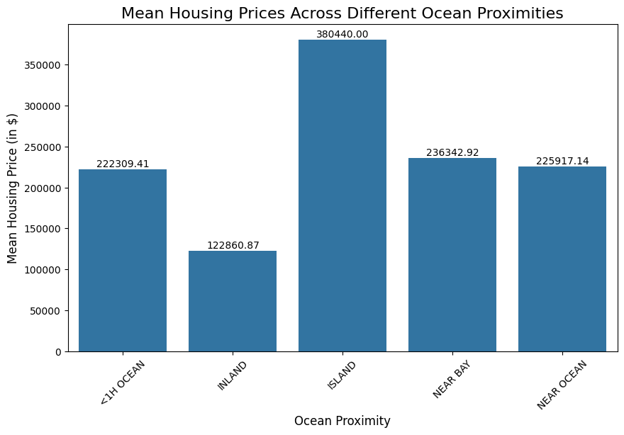

```python
import seaborn as sns
import matplotlib.pyplot as plt

# Group by ocean proximity and calculate the mean housing price for each category
mean_prices = data.groupby('ocean_proximity')['median_house_value'].mean().reset_index()

# Create a bar plot for the mean prices
plt.figure(figsize=(10, 6))
bar_plot = sns.barplot(x='ocean_proximity', y='median_house_value', data=mean_prices)

# Adding titles and labels
plt.title('Mean Housing Prices Across Different Ocean Proximities', fontsize=16)
plt.xlabel('Ocean Proximity', fontsize=12)
plt.ylabel('Mean Housing Price (in $)', fontsize=12)
plt.xticks(rotation=45)  # Rotate x-axis labels for better readability

# Adding value annotations on top of bars
for bar in bar_plot.patches:
    bar_height = bar.get_height()
    plt.text(bar.get_x() + bar.get_width() / 2, bar_height, f'{bar_height:.2f}',
             ha='center', va='bottom', fontsize=10)

plt.show()
```

Overall, the distribution of housing prices is skewed towards the ISLAND proximity, indicating that houses located near islands tend to have significantly higher prices compared to other locations. The proximity to the ocean has a noticeable impact on housing prices, with locations closer to the ocean generally having higher prices than those farther inland.

### 2. Analyze the Relationship Between Median Income and Housing Prices

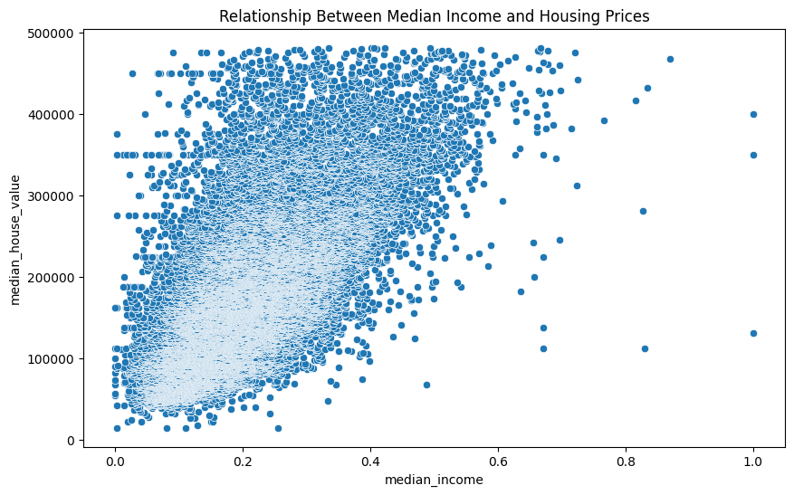

```python
# Relationship between median income and housing prices
plt.figure(figsize=(10, 6))
sns.scatterplot(x='median_income', y='median_house_value', data=data)
plt.title('Relationship Between Median Income and Housing Prices')
plt.show()
```

- Positive correlation: There is a clear positive correlation between median income and housing prices. As median income increases, housing prices tend to increase as well.
- Clustering: The data points cluster in certain areas of the plot, indicating that there might be other factors influencing housing prices besides median income.
- Outliers: There are a few outliers, especially at higher median income levels, suggesting that there might be some exceptional cases where housing prices are significantly higher or lower than expected based on median income alone.

Overall, the plot suggests a strong positive relationship between median income and housing prices, but there are also other factors that can influence housing prices.

## ML Model Training and Testing Tasks

### 1. Split the cleaned data into training and testing sets

```python
# Target variable is 'median_house_value' and features are the rest

# Features (X) and target (y)
X = data1.drop('median_house_value', axis=1).values
y = data1['median_house_value'].values

# Split the data (80% training, 20% testing)
train_size = int(0.8 * X.shape[0])
X_train, X_test = X[:train_size], X[train_size:]
y_train, y_test = y[:train_size], y[train_size:]

# Print the shape of the training and test sets
print(f"X_train shape: {X_train.shape}, y_train shape: {y_train.shape}")
print(f"X_test shape: {X_test.shape}, y_test shape: {y_test.shape}")
```

```
X_train shape: (15590, 9), y_train shape: (15590,)
X_test shape: (3898, 9), y_test shape: (3898,)
```

### 2. Implement the closed-form solution to linear regression

```python
# Add a column of ones to X_train and X_test for the intercept
X_train_b = np.c_[np.ones((X_train.shape[0], 1)), X_train]
X_test_b = np.c_[np.ones((X_test.shape[0], 1)), X_test]

# Closed-form solution for theta
theta = np.linalg.inv(X_train_b.T.dot(X_train_b)).dot(X_train_b.T).dot(y_train)

# Print the learned coefficients (theta)
print(f"Learned coefficients (theta): {theta}")
```

```
Learned coefficients (theta): [-2444048.97950046   -29765.83056681   -29222.42993703    14473.35707165
  -279291.98867024   375503.19019303  -486773.0720114    162606.5673157
   381328.12929269    -2932.24154522]
```

### 3. Print the learned coefficients (weights) of the model

```python
# Feature names (including intercept)
feature_names = ['Intercept'] + list(data1.drop('median_house_value', axis=1).columns)

# Print learned coefficients
for name, coef in zip(feature_names, theta):
    print(f"{name}: {coef}")

# Comment on which feature has the highest weight
max_weight_index = np.argmax(np.abs(theta[1:]))  # Exclude intercept
print(f"The feature '{feature_names[max_weight_index + 1]}' has the highest weight.")
```

```
Intercept: -2444048.97950046
longitude: -29765.830566806406
latitude: -29222.429937031928
housing_median_age: 14473.357071649065
total_rooms: -279291.9886702437
total_bedrooms: 375503.19019302685
population: -486773.0720113965
households: 162606.5673157001
median_income: 381328.129292692
ocean_proximity: -2932.2415452211003
The feature 'population' has the highest weight.
```

### 4. Generate predictions on the test dataset split

```python
# Predict on the test set
y_pred = X_test_b.dot(theta)

# Print the first 10 predictions and the actual values
print("Predicted house values (first 10):", y_pred[:10])
print("Actual house values (first 10):", y_test[:10])
```

```
Predicted house values (first 10): [184504.00665757 177137.71041049 173409.90548841 138206.56253939
 261776.39817333 211512.05817032 181241.54796707 110223.52413031
 211567.28751504 177364.187809  ]
Actual house values (first 10): [268800. 268800. 268800. 268800. 268800. 268800. 268800. 268800. 268900.
 268900.]
```

### 5. Implement evaluation metrics using Numpy

```python
# Mean Absolute Error (MAE)
mae = np.mean(np.abs(y_pred - y_test))

# Mean Squared Error (MSE)
mse = np.mean((y_pred - y_test) ** 2)

# Print the evaluation metrics
print(f"Mean Absolute Error (MAE): {mae}")
print(f"Mean Squared Error (MSE): {mse}")
```

```
Mean Absolute Error (MAE): 120556.0198863115
Mean Squared Error (MSE): 17864890379.829967
```

### 6. Evaluate the model's performance

```python
print(f"The model has a Mean Absolute Error of {mae:.2f} and Mean Squared Error of {mse:.2f}.")
print("Lower values of these metrics indicate a better model. However, high error could be due to linearity assumptions or lack of feature engineering.")
```

```
The model has a Mean Absolute Error of 120556.02 and Mean Squared Error of 17864890379.83.
Lower values of these metrics indicate a better model. However, high error could be due to linearity assumptions or lack of feature engineering.
```

### 7. [BONUS] Implement an additional metric

```python
# R-squared (R²)
ss_res = np.sum((y_test - y_pred) ** 2)  # Residual sum of squares
ss_tot = np.sum((y_test - np.mean(y_test)) ** 2)  # Total sum of squares
r2 = 1 - (ss_res / ss_tot)

# Print R²
print(f"R-squared (R²): {r2}")

# Comment on R²
print(f"An R² of {r2:.2f} means that the model explains approximately {r2*100:.2f}% of the variance in the house prices.")
```

```
R-squared (R²): -4.856081932266829
An R² of -4.86 means that the model explains approximately -485.61% of the variance in the house prices.
```